# GBI6 - BIOINFORMÁTICA

EXAMEN FINAL

Salcedo Marilyn

2022-03-17

[figure not shown]

**Bienvenidos al examen final de GBI6 - Bioinformática.**

# CONTENIDO DE LA EVALUACIÓN

Los contenidos de esta evaluación corresponden a los temas de R revisados en el curso:

- Tipos de datos
- Instalación y uso de librerías.
- Estructuras de control
- Funciones
- Manipulación de datos
- Estadística básica
- Visualización de datos

# INDICACIONES GENERALES

Esta permitido consultar todo material disponible: diapositivas, google…Sin embargo **NO** esta permitido consultar a sus colegas.

Ustedes estan utilizando el R Markdown. Las instruciones son:

- Creen una carpeta en su computador con el nombre “GBI6_ExamenFinal” donde guarden este cuaderno .Rmd.
- Cree un subdirectorio de nombre “data” donde guarde la data que van a utilizar.
- Cree un subdirectorio de nombre “results” donde guarde la tablas y figuras generadas del análisis.
- Definan a esa carpeta como su directorio de trabajo.
- Arriba, **solamente** donde dice “author”, deben llenar sus nombres.
- Los codigos deben ser escritos dentro de las cajas que inician y terminan con ``` o dentro de las cajas indicadas abajo de las preguntas.
- Al final del examen deben utilizar el comando “Knit” para generar un archivo .html
- Es recomendable crear una copia de este script guía.
- Genere controles de la versión para cada una de las preguntas con la leyenda “Nombre Apellido, resuelve el ejercicio XX”.
- Copie y peque la dirección de su repositorio de GitHub en la actividad **“ExamenFinal”**.
- Asegúrese de responder explícitamente cada una de las preguntas.

Para comprender la data de esta evaluación se requiere conocer el significado de algunos acrónimos de los tipos de cancer como indica el [Broad Institute Cancer Names](https://gdac.broadinstitute.org/). Asimismo revise la información de ayuda para `expresionsTCGA`. La data contiene las columnas:

- **bcr_patient_barcode**: es el identificador del paciente.
- **dataset**: es el identificador del tipo de cancer del paciente.
- **resto de columnas**: nivees de expresión de los diferentes mRNA de los genes que están como nombre de columna (para este análisis se han seleccionado solamente 7 de ellos).

# PREGUNTAS

## **Pregunta 1: MANIPULACIÓN DE DATOS [4 PUNTOS]**

### [0.5 PUNTOS] 1.1 Defina su directorio de trabajo.

```r
setwd("~/R/GBI6_ExamenFinal")
```

### [0.5 PUNTOS] 1.2. Cargue la data “mRNA_expr.csv”

```
##   bcr_patient_barcode dataset   GATA3      PTEN     XBP1    ESR1     MUC1
## 1               BRCA1    BRCA 2.87050 1.3613571 2.983333 3.08425 1.652125
## 2               BRCA2    BRCA 2.16625 0.4283571 2.550833 2.38600 3.080250
##        FN1      GAPDH
## 1 1.733375 -1.6291667
## 2 0.217625 -0.9511667
```

### [1 PUNTO] 1.3 Cree una función de nombre `long_df` para transformar la data `df` de la forma wide a long.

```r
library(tidyverse)
# Escriba aquí la función long_df
long_df = function(df){
  df%>%
    pivot_longer(!c(bcr_patient_barcode,dataset),names_to = "gen",values_to = "expresion_level")%>%
    select(dataset,gen,expresion_level)
}
```

### [1 PUNTO] Genere la data `df_long` utilizandola función `long_df`.

La tabla resultante tendrá tres columnas: `dataset, gen, expresion_level`.

```r
# Genere la data df_long
df_long=long_df(df)
head(df_long,5)
```

```
## # A tibble: 5 x 3
##   dataset gen   expresion_level
##   <chr>   <chr>           <dbl>
## 1 BRCA    GATA3            2.87
## 2 BRCA    PTEN             1.36
## 3 BRCA    XBP1             2.98
## 4 BRCA    ESR1             3.08
## 5 BRCA    MUC1             1.65
```

```r
#install.packages("sjPlot")
library(sjPlot)
library(sjmisc)
df_long=df_long%>%group_by(dataset,gen)
desc_table=descr(df_long)
# Escriba el código para crear el Descriptive table
```

## **Pregunta 2 VISUALIZACION DE DATOS [5 PUNTOS]**

Para esta pregunta tiene que utilizar la data `df_long`.

### [1 PUNTO] 2.1 Cree la funcion `tcga_boxplots` para visualizar boxplots y jitterplots. El único parámetro de la función es `dataset`. La función debe crear un boxplot de los niveles de expresión para cada gen.

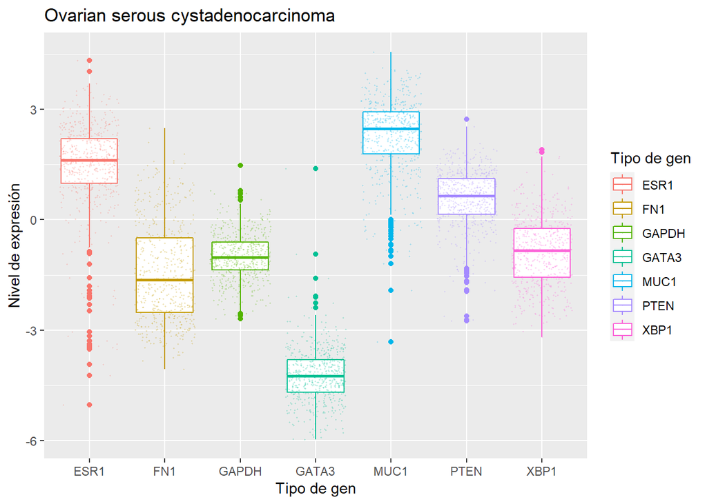

```r
library(ggplot2)
abr=unique(df_long$dataset)
name=c("Breast invasive carcinoma","Ovarian serous cystadenocarcinoma","Lung squamous cell carcinoma","Pan-kidney cohort","Kidney renal papillary cell carcinoma","Uterine Corpus Endometrial Carcinoma")
tcga_boxplots=function(df_long){
  df_long%>%
    ggplot(aes(x=factor(gen),y=expresion_level,color=factor(gen)))+
  geom_boxplot() + geom_jitter(alpha=0.2, size = 0.2)+
    labs(x = "Tipo de gen",
       y = "Nivel de expresión",color = "Tipo de gen",
       title = name[which(abr==df_long$dataset[1])])
}
boxplot1=df_long%>%filter(dataset=="OV")%>%tcga_boxplots()
boxplot1
```

### [0.5 PUNTOS] 2.2 Utilizando la función `lapply()` genera la lista `cancertype_boxplots` con las gráficas para cada tipo de cancer (cada tipo de dataset).

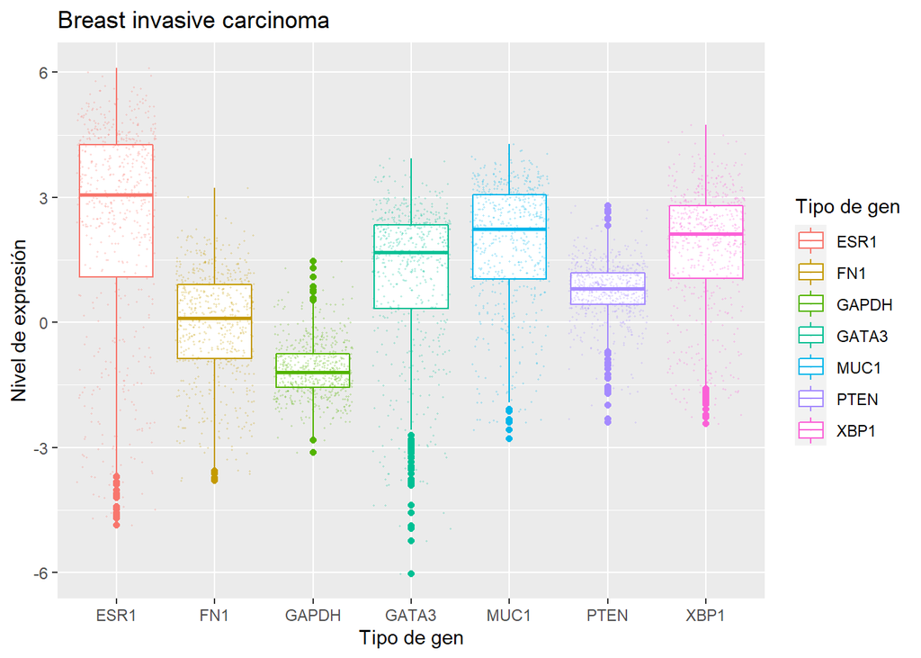

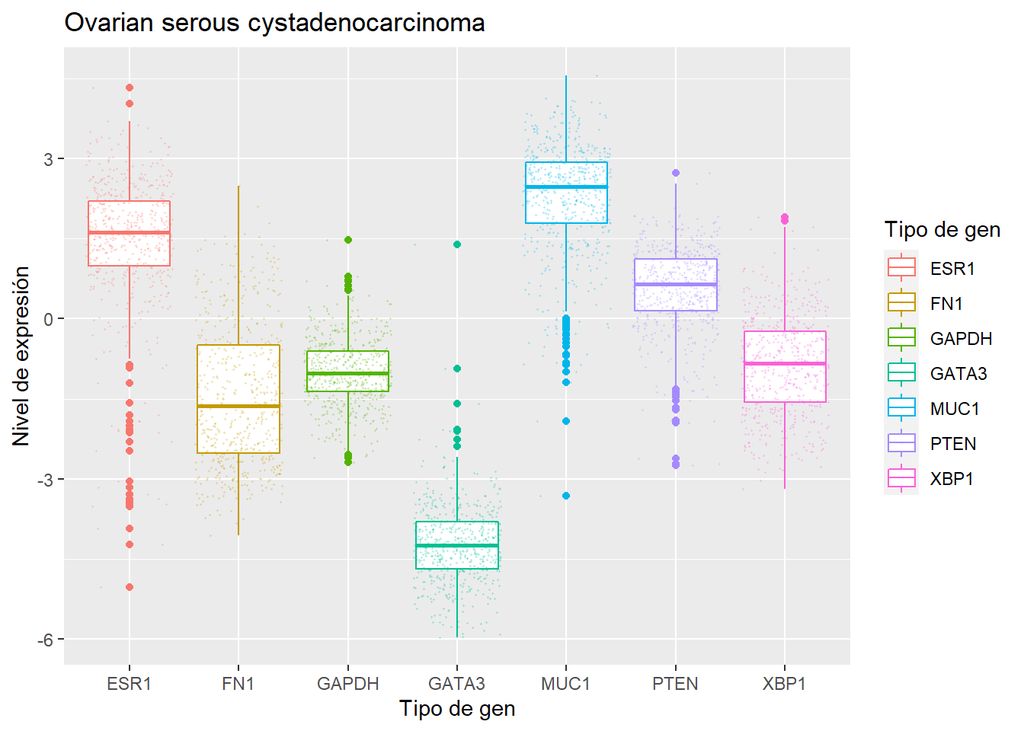

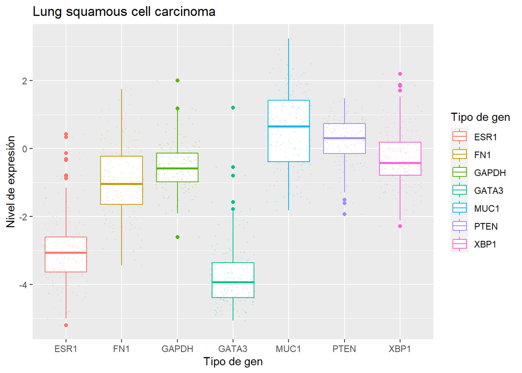

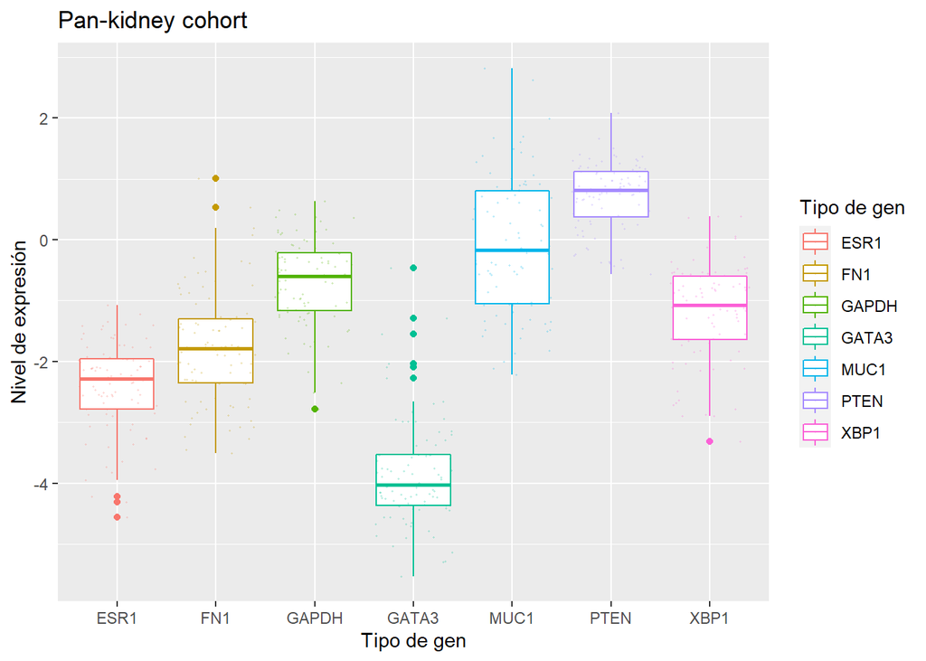

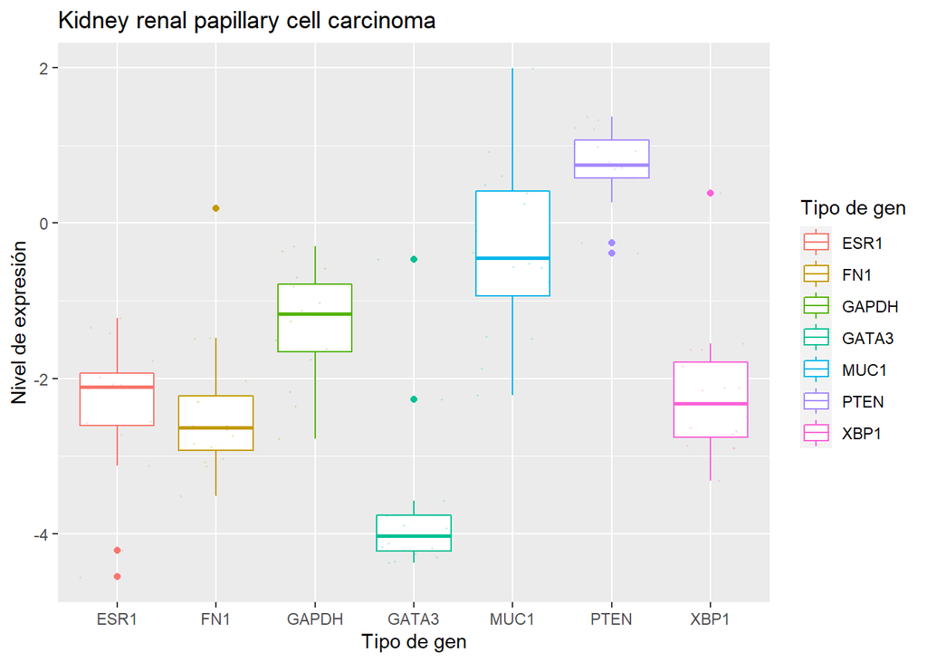

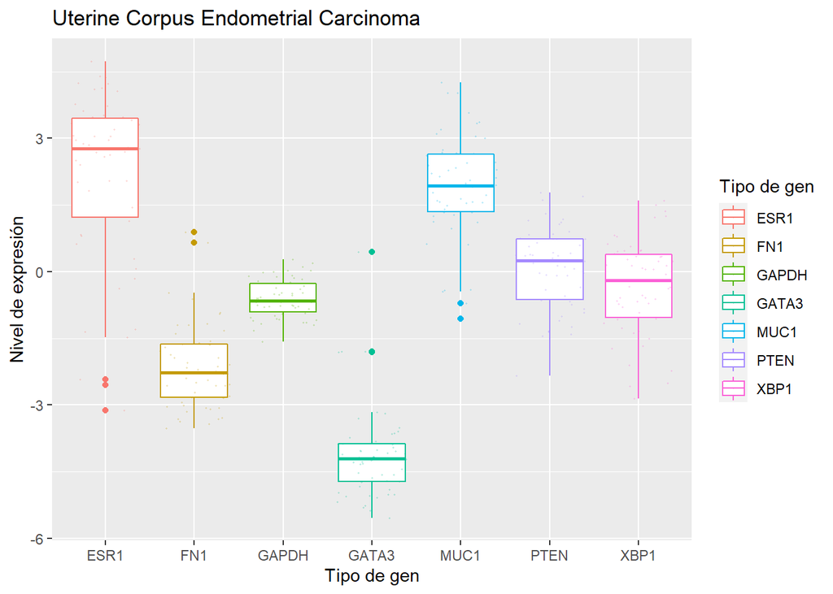

```r
# Escriba el código para generar la lista.
cancertype=list(df_long%>%filter(dataset==abr[1]))
for (i in 2:length(abr)) {
  cancertype=c(cancertype,list(df_long%>%filter(dataset==abr[i])))
}
cancertype_boxplots=lapply(cancertype,tcga_boxplots)
cancertype_boxplots
```

```r
# Escriba el código para guardar la tercera figura de la lista.
ggsave(cancertype_boxplots[[3]], file="results/boxplot3.jpg", width=10, height=12,dpi = 300)
```

### [1 PUNTO] 2.4 Escriba la función `reg_gen_expression`, con el parámetro `gen`. En este caso la función visualizará una gráfica de nube de puntos (geom_point) y una regresión por tipo de “dataset”. La gráfica será de comparación de gen1 con gen2; por ejemplo en el eje “x” `GATA3` y en el eje “y”” `FN1`.

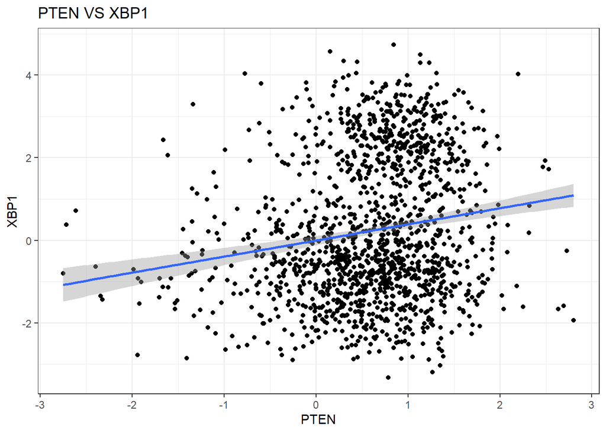

```r
# Escriba aquí su función reg_gen_expression
i=2
genes=colnames(df)[3:9]
df_reg=as.data.frame(cbind(df[,i+2],df[,i+3]))
colnames(df_reg)[1]=genes[i]
colnames(df_reg)[2]=genes[i+1]

reg_gen_expression=function(df_reg){
  namex=colnames(df_reg[1])
  namey=colnames(df_reg[2])
  df_reg%>%ggplot(aes(x=df_reg[,1],y=df_reg[,2]))+
    geom_point()+
    geom_smooth(method = "lm",formula = y~x)+
  labs(x = namex,
       y = namey,
       title = paste(namex,namey,sep = " VS "))+
    theme_bw()
}

reg_gen_expression(df_reg)
```

### [0.5 PUNTOS] 2.5. Utilizando la función `lapply()` genera la lista `reg_genplots` con las gráficas para cada par de genes posibles. Recuerde que tiene 7 tipos de genes, se debe tener todas las combinaciones posibles por pares de genes (combinatoria sin repetición).

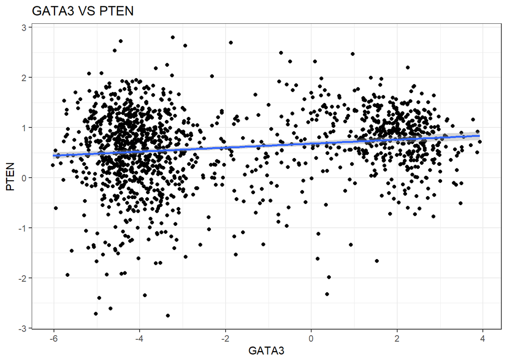

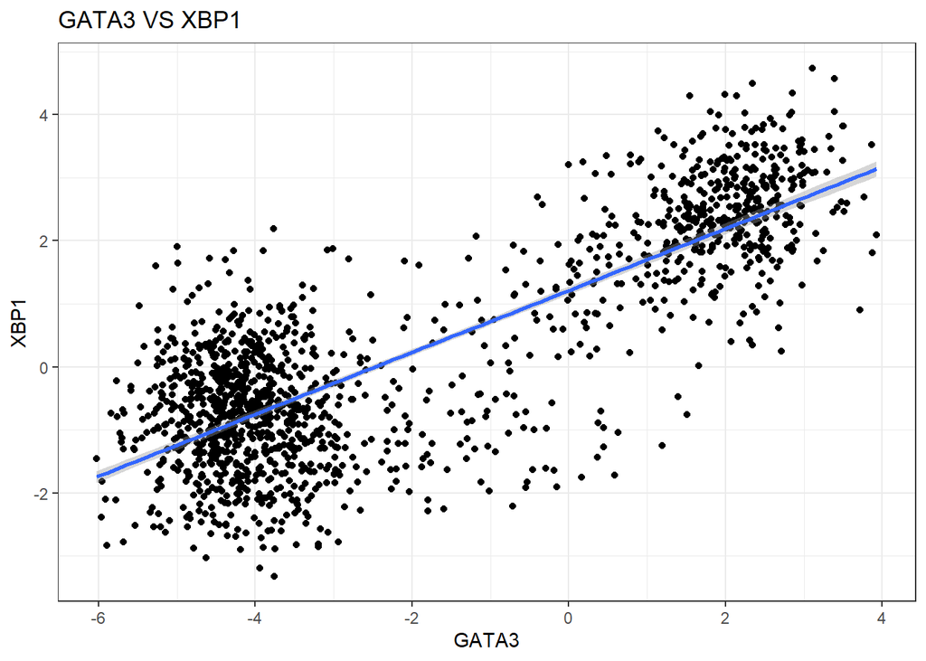

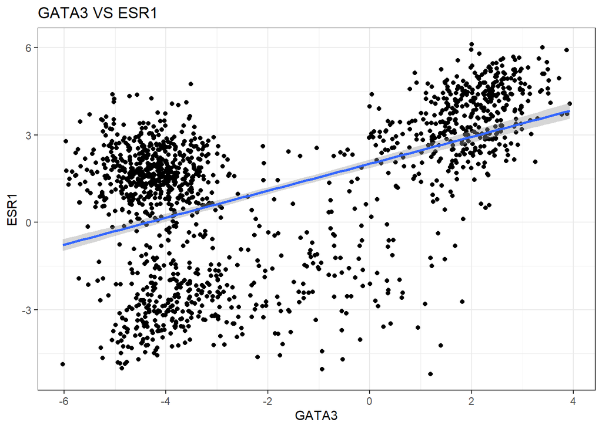

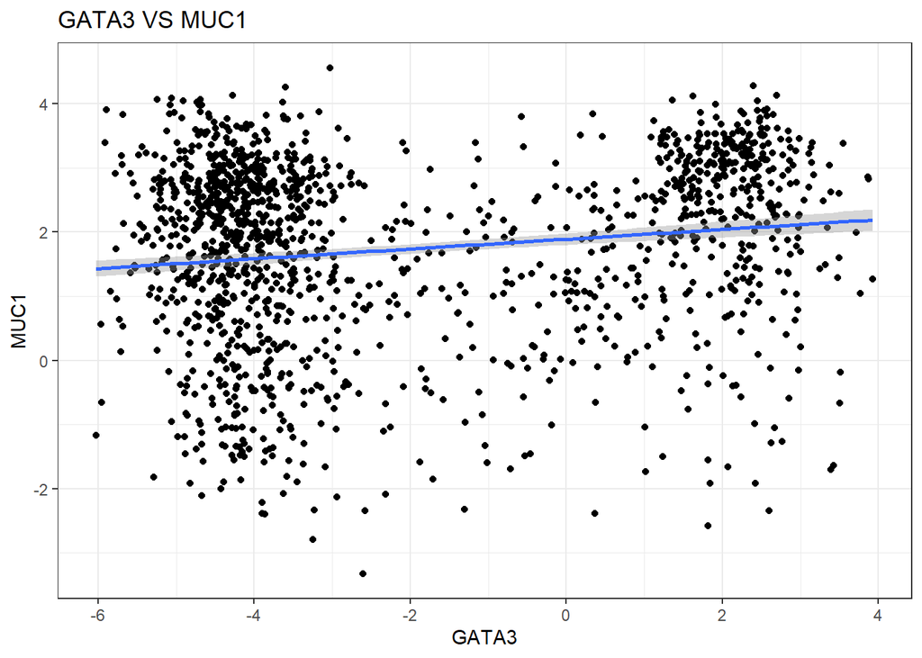

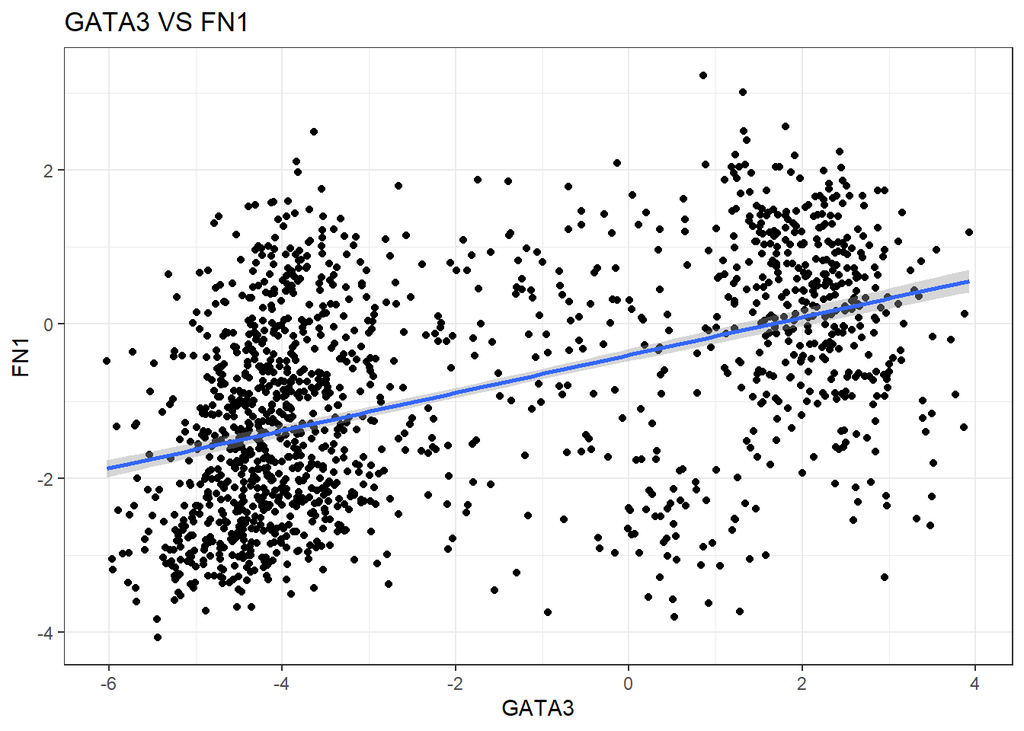

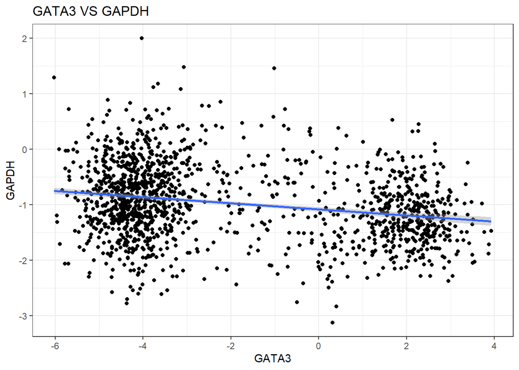

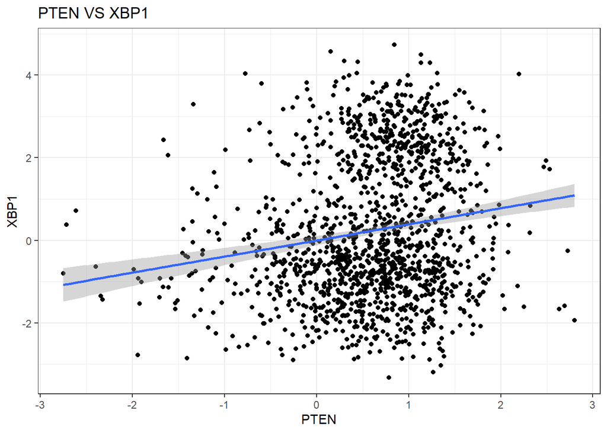

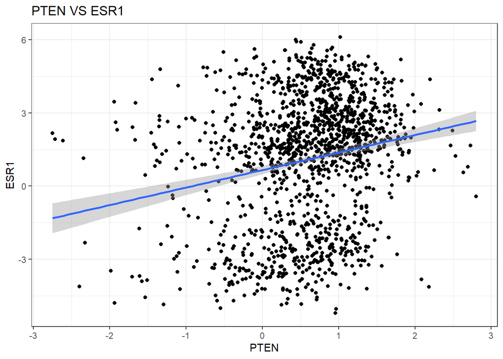

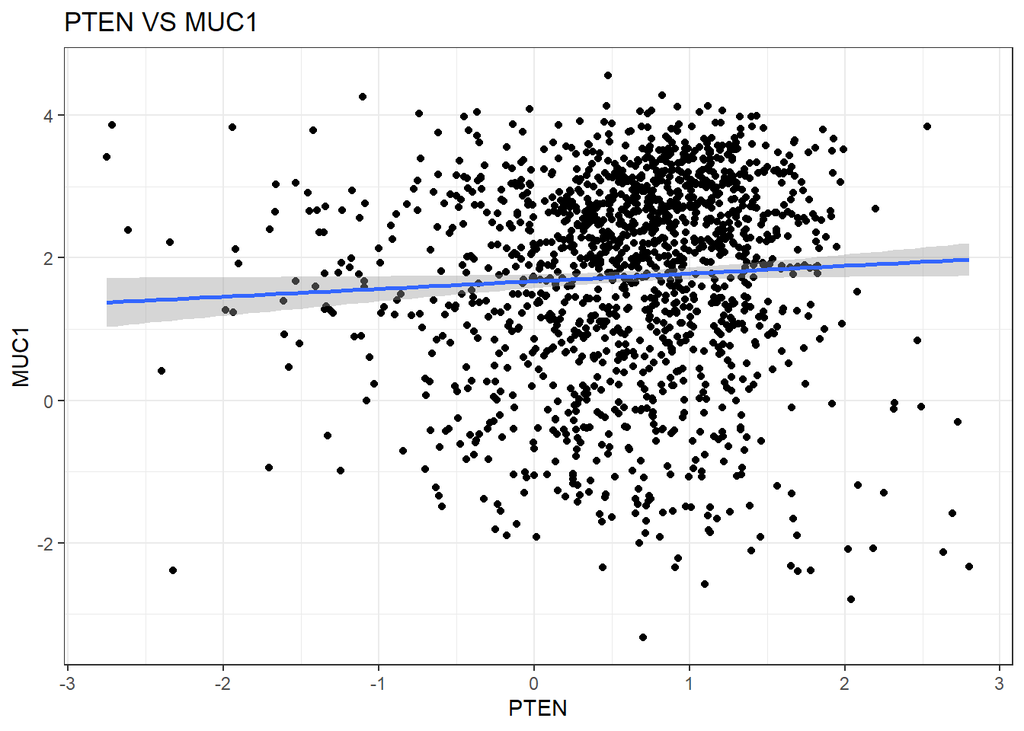

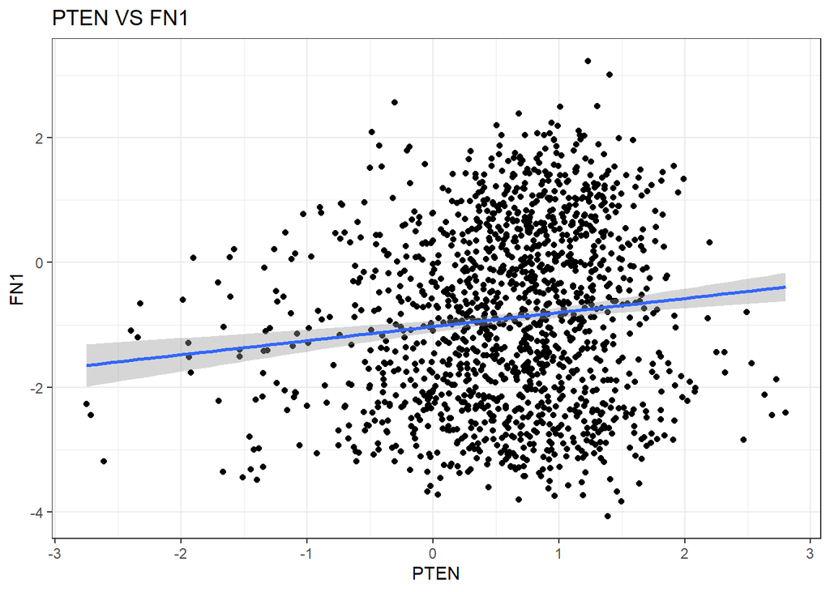

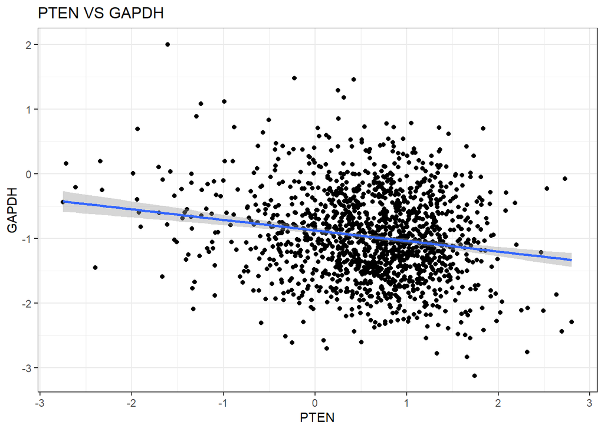

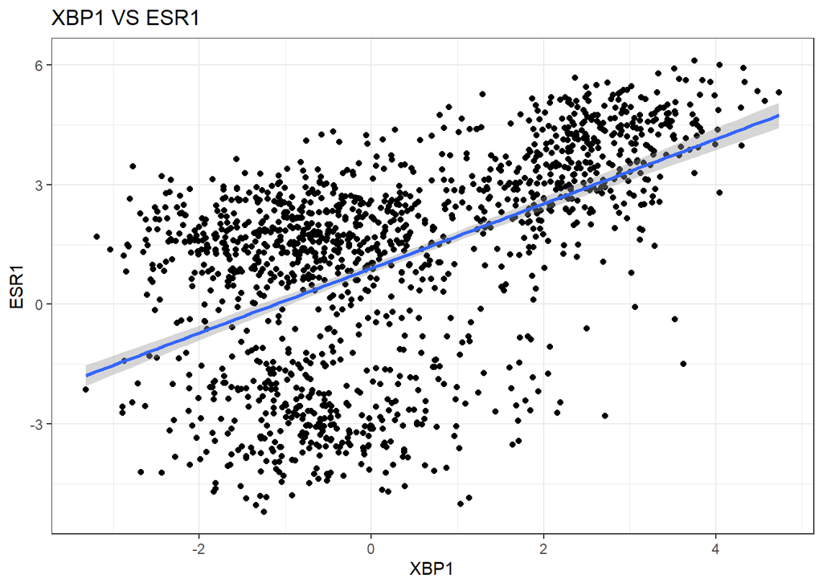

[9 more figures not shown]

```r
# Escriba el código para generar la lista.

combi=combn(genes,m=2,simplify = F)

gen1=combi[[1]][1]
gen2=combi[[1]][2]

i=which(gen1==genes)
j=which(gen2==genes)

df_reg=as.data.frame(cbind(df[,i+2],df[,j+2]))
colnames(df_reg)[1]=genes[i]
colnames(df_reg)[2]=genes[j]


df_reg_list=list(df_reg)
for (i in 2:length(combi)) {
  gen1=combi[[i]][1]
  gen2=combi[[i]][2]

  j=which(gen1==genes)
  k=which(gen2==genes)

  df_reg=as.data.frame(cbind(df[,j+2],df[,k+2]))
  colnames(df_reg)[1]=genes[j]
  colnames(df_reg)[2]=genes[k]

  df_reg_list=c(df_reg_list,list(df_reg))
}

reg_genplots=lapply(df_reg_list,reg_gen_expression)
reg_genplots
```